# Project 7: Difference-in-Differences and Synthetic Control

```r
# Install and load packages
if (!require("pacman")) install.packages("pacman")
devtools::install_github("ebenmichael/augsynth")
```

```r
pacman::p_load(# Tidyverse packages including dplyr and ggplot2
               tidyverse,
               ggthemes,
               augsynth,
               gsynth)

# set seed
set.seed(44)

# load data
medicaid_expansion <- read_csv('/Users/jama/Documents/GitHub/Computational-Social-Science-Projects/Project_7/data/medicaid_expansion.csv')
```

# Introduction

For this project, you will explore the question of whether the Affordable Care Act increased health insurance coverage (or conversely, decreased the number of people who are uninsured). The ACA was passed in March 2010, but several of its provisions were phased in over a few years. The ACA instituted the “individual mandate” which required that all Americans must carry health insurance, or else suffer a tax penalty. There are four mechanisms for how the ACA aims to reduce the uninsured population:

- Require companies with more than 50 employees to provide health insurance.
- Build state-run healthcare markets (“exchanges”) for individuals to purchase health insurance.
- Provide subsidies to middle income individuals and families who do not qualify for employer based coverage.
- Expand Medicaid to require that states grant eligibility to all citizens and legal residents earning up to 138% of the federal poverty line. The federal government would initially pay 100% of the costs of this expansion, and over a period of 5 years the burden would shift so the federal government would pay 90% and the states would pay 10%.

In 2012, the Supreme Court heard the landmark case NFIB v. Sebelius, which principally challenged the constitutionality of the law under the theory that Congress could not institute an individual mandate. The Supreme Court ultimately upheld the individual mandate under Congress’s taxation power, but struck down the requirement that states must expand Medicaid as impermissible subordination of the states to the federal government. Subsequently, several states refused to expand Medicaid when the program began on January 1, 2014. This refusal created the “Medicaid coverage gap” where there are indivudals who earn too much to qualify for Medicaid under the old standards, but too little to qualify for the ACA subsidies targeted at middle-income individuals.

States that refused to expand Medicaid principally cited the cost as the primary factor. Critics pointed out however, that the decision not to expand primarily broke down along partisan lines. In the years since the initial expansion, several states have opted into the program, either because of a change in the governing party, or because voters directly approved expansion via a ballot initiative.

You will explore the question of whether Medicaid expansion reduced the uninsured population in the U.S. in the 7 years since it went into effect. To address this question, you will use difference-in-differences estimation, and synthetic control.

# Data

The dataset you will work with has been assembled from a few different sources about Medicaid. The key variables are:

- **State**: Full name of state
- **Medicaid Expansion Adoption**: Date that the state adopted the Medicaid expansion, if it did so.
- **Year**: Year of observation.
- **Uninsured rate**: State uninsured rate in that year.

# Exploratory Data Analysis

Create plots and provide 1-2 sentence analyses to answer the following questions:

- Which states had the highest uninsured rates prior to 2014? The lowest?
- Which states were home to most uninsured Americans prior to 2014? How about in the last year in the data set? **Note**: 2010 state population is provided as a variable to answer this question. In an actual study you would likely use population estimates over time, but to simplify you can assume these numbers stay about the same.

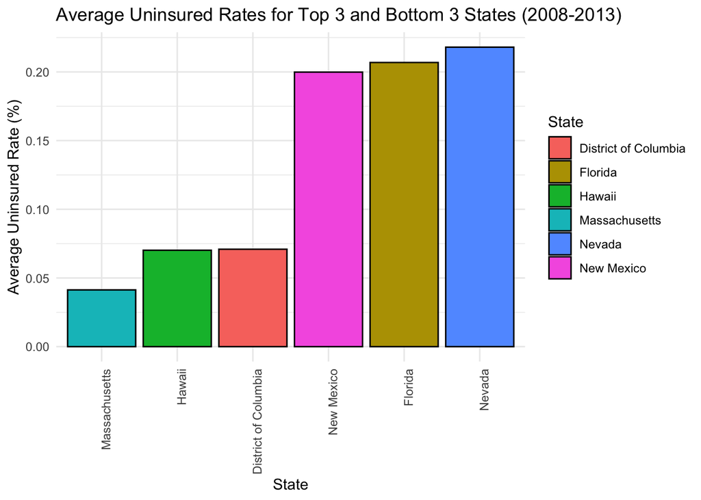

```r
# highest and lowest uninsured rates


# Filter the data for the years 2008 to 2013, calculate average uninsured rates, then sort and select top and bottom 3 states
top_bottom_states_avg <- medicaid_expansion %>%
  filter(year >= 2008, year <= 2013) %>%
  group_by(State) %>%
  summarise(avg_uninsured_rate = mean(uninsured_rate, na.rm = TRUE)) %>%
  ungroup() %>%
  arrange(desc(avg_uninsured_rate)) %>%
  slice(c(1:3, (n()-2):n()))

# Create the bar graph
ggplot(top_bottom_states_avg, aes(x = reorder(State, avg_uninsured_rate), y = avg_uninsured_rate, fill = State)) +
  geom_bar(stat = "identity", color = "black") +
  labs(title = "Average Uninsured Rates for Top 3 and Bottom 3 States (2008-2013)",
       x = "State",
       y = "Average Uninsured Rate (%)") +
  theme_minimal() +
  theme(axis.text.x = element_text(angle = 90, hjust = 1)) # Rotate x-axis labels for better readability
```

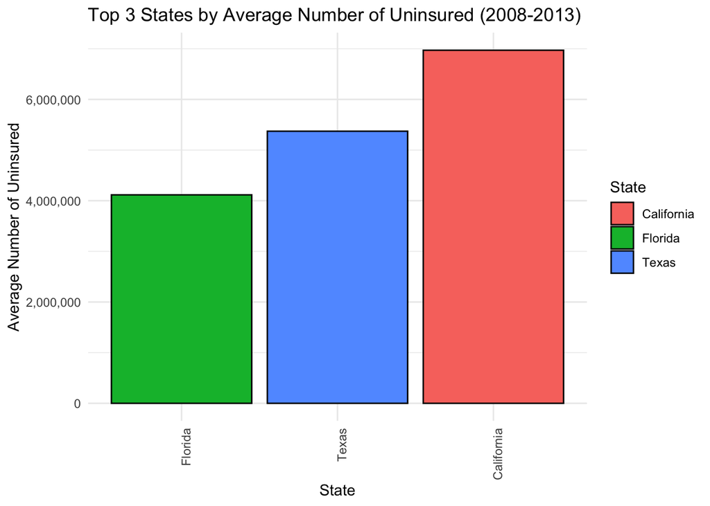

```r
# most uninsured Americans
# I will create a new variable for the number of Americans uninsured in a state per year
medicaid_expansion$uninsured_count <- medicaid_expansion$uninsured_rate * medicaid_expansion$population

medicaid_expansion_noDC <- medicaid_expansion %>%
  filter(State != "District of Columbia")

# Filter and calculate the averages as before, then arrange
top_bottom_states_avg_count <- medicaid_expansion_noDC %>%
  filter(year >= 2008, year <= 2013) %>%
  group_by(State) %>%
  summarise(avg_uninsured_count = mean(uninsured_count, na.rm = TRUE)) %>%
  ungroup() %>%
  arrange(desc(avg_uninsured_count)) %>%
  mutate(rank = row_number())  # Assign a rank after arranging

# Separate data for top 3 and bottom 3
top_3_states <- filter(top_bottom_states_avg_count, rank <= 3)
bottom_3_states <- filter(top_bottom_states_avg_count, rank >= (n() - 2))

# Create the bar graph for top 3 states
top_3_plot <- ggplot(top_3_states, aes(x = reorder(State, avg_uninsured_count), y = avg_uninsured_count, fill = State)) +
  geom_bar(stat = "identity", color = "black") +
  labs(title = "Top 3 States by Average Number of Uninsured (2008-2013)",
       x = "State",
       y = "Average Number of Uninsured") +
  scale_y_continuous(labels = scales::comma) +
  theme_minimal() +
  theme(axis.text.x = element_text(angle = 90, hjust = 1))

# Create the bar graph for bottom 3 states
bottom_3_plot <- ggplot(bottom_3_states, aes(x = reorder(State, avg_uninsured_count), y = avg_uninsured_count, fill = State)) +
  geom_bar(stat = "identity", color = "black") +
  labs(title = "Bottom 3 States by Average Number of Uninsured (2008-2013)",
       x = "State",
       y = "Average Number of Uninsured") +
  scale_y_continuous(labels = scales::comma) +
  theme_minimal() +
  theme(axis.text.x = element_text(angle = 90, hjust = 1))

print(top_3_plot)
```

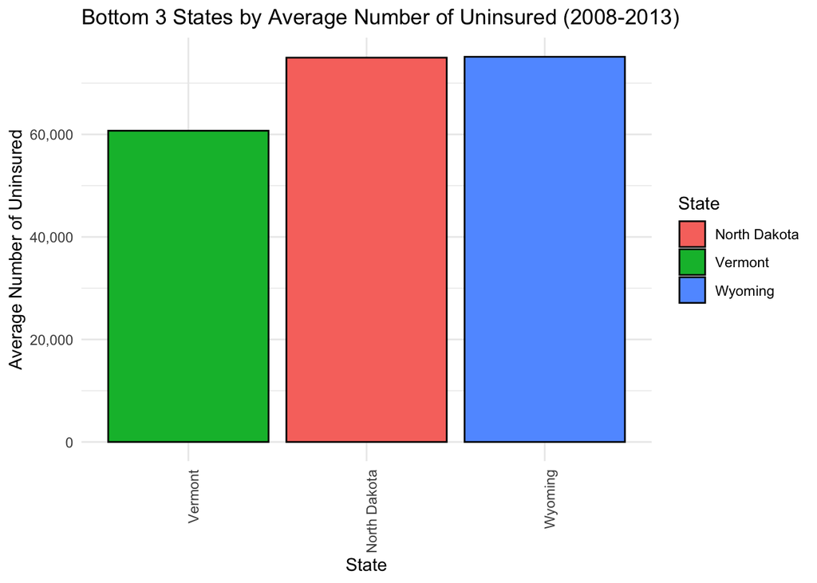

```r
print(bottom_3_plot)
```

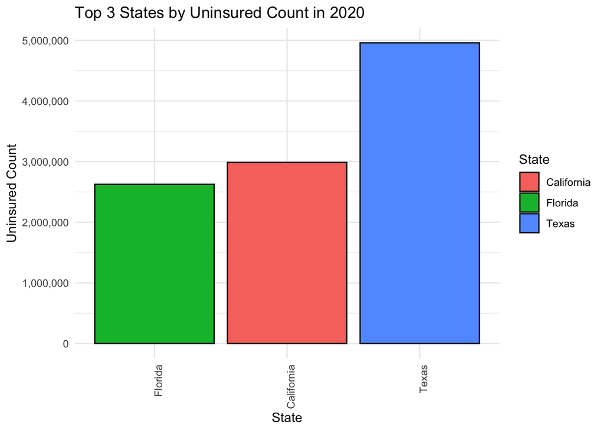

```r
#Now Ill do it for the year 2020

# Filter for the year 2020
top_bottom_states_2020 <- medicaid_expansion_noDC %>%
  filter(year == 2020) %>%
  arrange(desc(uninsured_count)) %>%
  mutate(rank = row_number())  # Assign a rank after arranging

# Separate data for top 3 and bottom 3
top_3_states_2020 <- filter(top_bottom_states_2020, rank <= 3)
bottom_3_states_2020 <- filter(top_bottom_states_2020, rank >= (n() - 2))

# Create the bar graph for top 3 states
top_3_plot_2020 <- ggplot(top_3_states_2020, aes(x = reorder(State, uninsured_count), y = uninsured_count, fill = State)) +
  geom_bar(stat = "identity", color = "black") +
  labs(title = "Top 3 States by Uninsured Count in 2020",
       x = "State",
       y = "Uninsured Count") +
  scale_y_continuous(labels = scales::comma) +
  theme_minimal() +
  theme(axis.text.x = element_text(angle = 90, hjust = 1))

# Create the bar graph for bottom 3 states
bottom_3_plot_2020 <- ggplot(bottom_3_states_2020, aes(x = reorder(State, uninsured_count), y = uninsured_count, fill = State)) +
  geom_bar(stat = "identity", color = "black") +
  labs(title = "Bottom 3 States by Uninsured Count in 2020",
       x = "State",
       y = "Uninsured Count") +
  scale_y_continuous(labels = scales::comma) +
  theme_minimal() +
  theme(axis.text.x = element_text(angle = 90, hjust = 1))

print(top_3_plot_2020)
```

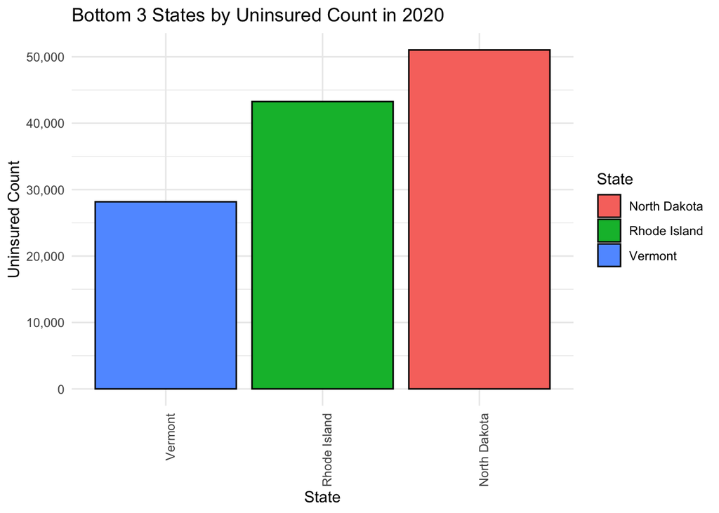

```r
print(bottom_3_plot_2020)
```